# POC2 potential counties

Published

October 26, 2023

```r
# load spatial data: w11_st = western 11 state boundaries; wcs_pl = western 11
# wcs landscapes; w11_cnty = western 11 counties

load('cnty_spatial_data.Rdata')

poc2_wcs <- c('Central Oregon',
              'Central Washington Initiative',
              'Colorado Front Range',
              'Southwest Idaho')

# function for defining adjacency
st_queen <- function(a, b = a) st_relate(a, b, pattern = "F***T****")

wcs_pl <- wcs_pl |> mutate(POC2 = ifelse(Name %in% poc2_wcs, 1, 0))

# function for finding counties that intersect with given input list
find_intersecting_counties <- function(cnty_lst){

  wcs_cnty_list <- cnty_lst |>
    st_join(w11_cnty) |>
    st_drop_geometry()

  cnty_int <- w11_cnty |>
    filter(geoid %in% unique(wcs_cnty_list$geoid)) |>
    select(geoid, name2, state)

  x <- cnty_int |>
    st_queen(w11_cnty) |>
    unlist() |>
    unique() |>
    sort()

  cnty_adj <- w11_cnty[x,] |>
    select(geoid, name2, state)

  # return 2 item list: (1) intersecting counties, (2) adjacent counties
  return(list(cnty_int, cnty_adj))
}

# counties that intersect with POC2 landscapes
tier1 <- wcs_pl |>
  filter(Year == 2022 & POC2 == 1) |>
  find_intersecting_counties()
```

```
although coordinates are longitude/latitude, st_relate_pattern assumes that
they are planar
```

```r
# remaining counties that intersect with WCS YR1 landscapes
tier2 <- wcs_pl |>
  filter(Year == 2022 & POC2 == 0) |>
  find_intersecting_counties()
```

```
although coordinates are longitude/latitude, st_relate_pattern assumes that
they are planar
```

```r
# counties that intersect with WCS YR2 landscapes
tier3 <- wcs_pl |>
  filter(Year == 2023 & POC2 == 0) |>
  find_intersecting_counties()
```

```
although coordinates are longitude/latitude, st_relate_pattern assumes that
they are planar
```

```r
# combine tiered lists together
tier123 <- bind_rows(
  tier1 |> pluck(1) |> mutate(group = 'POC2 Intersect'),
  tier1 |> pluck(2) |> mutate(group = 'POC2 Adjacent'),
  tier2 |> pluck(1) |> mutate(group = 'WCS1 Intersect'),
  tier2 |> pluck(2) |> mutate(group = 'WCS1 Adjacent'),
  tier3 |> pluck(1) |> mutate(group = 'WCS2 Intersect'),
  tier3 |> pluck(2) |> mutate(group = 'WCS2 Adjacent')
)

# remove duplicate counties
tier123 <- tier123 |>
  st_drop_geometry() |>
  group_by(geoid) |>
  slice_head(n = 1)
```

Below is a map of counties the intersect or are adjacent to intersected counties that we are considering evaluating as part of POC2. I’ve organized the counties into 3 tiers each with 2 groups. Tier 1 is our primary focus; Tier 2 is our secondary focus; Tier 3 is are stretch goal. In each Tier, group `_1` contains counties that intersect the WCS priority landscapes, group `_2` contains counties that are adjacent to those counties.

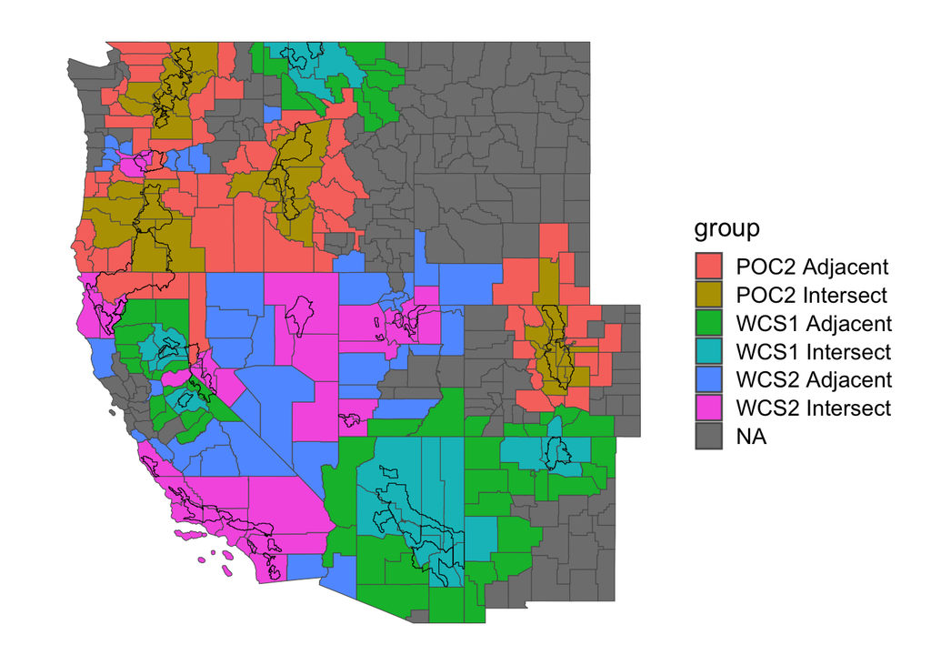

```r
# join tiered county list to the county spatial data
w11_cnty2 <- w11_cnty |>
  left_join(tier123)
ggplot(w11_cnty2) +
  geom_sf(aes(fill=group)) +
  geom_sf(data = wcs_pl, fill=NA, color='black') +
  theme_map()
```

Below is the list of counties intersecting (n=38) or adjacent (n=64) to the 4 priority landscapes which are the primary focus of the POC2.

```r
tier123_1 <- tier123 |>
  filter(group %in% c('POC2 Intersect','POC2 Adjacent'))
table(tier123_1$group)
```

```
 POC2 Adjacent POC2 Intersect
            64             38
```

```r
tier123_1 |> arrange(group) |> kable()
```

| geoid | name2 | state | group |
| --- | --- | --- | --- |
| 06049 | Modoc County | CA | POC2 Adjacent |
| 06093 | Siskiyou County | CA | POC2 Adjacent |
| 08001 | Adams County | CO | POC2 Adjacent |
| 08014 | Broomfield County | CO | POC2 Adjacent |
| 08015 | Chaffee County | CO | POC2 Adjacent |
| 08027 | Custer County | CO | POC2 Adjacent |
| 08037 | Eagle County | CO | POC2 Adjacent |
| 08039 | Elbert County | CO | POC2 Adjacent |
| 08057 | Jackson County | CO | POC2 Adjacent |
| 08065 | Lake County | CO | POC2 Adjacent |
| 08073 | Lincoln County | CO | POC2 Adjacent |
| 08101 | Pueblo County | CO | POC2 Adjacent |
| 08107 | Routt County | CO | POC2 Adjacent |
| 08109 | Saguache County | CO | POC2 Adjacent |
| 08121 | Washington County | CO | POC2 Adjacent |
| 08123 | Weld County | CO | POC2 Adjacent |
| 16013 | Blaine County | ID | POC2 Adjacent |
| 16025 | Camas County | ID | POC2 Adjacent |
| 16027 | Canyon County | ID | POC2 Adjacent |
| 16035 | Clearwater County | ID | POC2 Adjacent |
| 16037 | Custer County | ID | POC2 Adjacent |
| 16047 | Gooding County | ID | POC2 Adjacent |
| 16059 | Lemhi County | ID | POC2 Adjacent |
| 16061 | Lewis County | ID | POC2 Adjacent |
| 16069 | Nez Perce County | ID | POC2 Adjacent |
| 16073 | Owyhee County | ID | POC2 Adjacent |
| 16075 | Payette County | ID | POC2 Adjacent |
| 16083 | Twin Falls County | ID | POC2 Adjacent |
| 30063 | Missoula County | MT | POC2 Adjacent |
| 30081 | Ravalli County | MT | POC2 Adjacent |

[output cut: 72 more lines]

Next is the list of counties intersecting (n=24) or adjacent (n=51) to the 6 additional priority landscapes identified in the roll out of the Wildfire Crisis Strategy (WCS).

```r
tier123_2 <- tier123 |>
  filter(group %in% c('WCS1 Intersect','WCS1 Adjacent'))
table(tier123_2$group)
```

```
 WCS1 Adjacent WCS1 Intersect
            51             24
```

```r
tier123_2 |> arrange(group) |> kable()
```

| geoid | name2 | state | group |
| --- | --- | --- | --- |
| 04003 | Cochise County | AZ | WCS1 Adjacent |
| 04012 | La Paz County | AZ | WCS1 Adjacent |
| 04013 | Maricopa County | AZ | WCS1 Adjacent |
| 04015 | Mohave County | AZ | WCS1 Adjacent |
| 04019 | Pima County | AZ | WCS1 Adjacent |
| 04021 | Pinal County | AZ | WCS1 Adjacent |
| 06003 | Alpine County | CA | WCS1 Adjacent |
| 06005 | Amador County | CA | WCS1 Adjacent |
| 06011 | Colusa County | CA | WCS1 Adjacent |
| 06021 | Glenn County | CA | WCS1 Adjacent |
| 06035 | Lassen County | CA | WCS1 Adjacent |
| 06039 | Madera County | CA | WCS1 Adjacent |
| 06043 | Mariposa County | CA | WCS1 Adjacent |
| 06051 | Mono County | CA | WCS1 Adjacent |
| 06061 | Placer County | CA | WCS1 Adjacent |
| 06077 | San Joaquin County | CA | WCS1 Adjacent |
| 06089 | Shasta County | CA | WCS1 Adjacent |
| 06099 | Stanislaus County | CA | WCS1 Adjacent |
| 06101 | Sutter County | CA | WCS1 Adjacent |
| 06103 | Tehama County | CA | WCS1 Adjacent |
| 08003 | Alamosa County | CO | WCS1 Adjacent |
| 08007 | Archuleta County | CO | WCS1 Adjacent |
| 08021 | Conejos County | CO | WCS1 Adjacent |
| 08055 | Huerfano County | CO | WCS1 Adjacent |
| 08071 | Las Animas County | CO | WCS1 Adjacent |
| 08083 | Montezuma County | CO | WCS1 Adjacent |
| 16017 | Bonner County | ID | WCS1 Adjacent |
| 16079 | Shoshone County | ID | WCS1 Adjacent |
| 30035 | Glacier County | MT | WCS1 Adjacent |
| 30047 | Lake County | MT | WCS1 Adjacent |
| 30049 | Lewis and Clark County | MT | WCS1 Adjacent |
| 30061 | Mineral County | MT | WCS1 Adjacent |
| 30073 | Pondera County | MT | WCS1 Adjacent |
| 30077 | Powell County | MT | WCS1 Adjacent |
| 30099 | Teton County | MT | WCS1 Adjacent |
| 35006 | Cibola County | NM | WCS1 Adjacent |
| 35017 | Grant County | NM | WCS1 Adjacent |
| 35021 | Harding County | NM | WCS1 Adjacent |
| 35023 | Hidalgo County | NM | WCS1 Adjacent |
| 35028 | Los Alamos County | NM | WCS1 Adjacent |
| 35031 | McKinley County | NM | WCS1 Adjacent |
| 35043 | Sandoval County | NM | WCS1 Adjacent |
| 35045 | San Juan County | NM | WCS1 Adjacent |
| 35047 | San Miguel County | NM | WCS1 Adjacent |
| 35049 | Santa Fe County | NM | WCS1 Adjacent |
| 35051 | Sierra County | NM | WCS1 Adjacent |
| 35053 | Socorro County | NM | WCS1 Adjacent |
| 35059 | Union County | NM | WCS1 Adjacent |
| 49025 | Kane County | UT | WCS1 Adjacent |
| 49037 | San Juan County | UT | WCS1 Adjacent |
| 53051 | Pend Oreille County | WA | WCS1 Adjacent |
| 04001 | Apache County | AZ | WCS1 Intersect |
| 04005 | Coconino County | AZ | WCS1 Intersect |
| 04007 | Gila County | AZ | WCS1 Intersect |
| 04009 | Graham County | AZ | WCS1 Intersect |
| 04011 | Greenlee County | AZ | WCS1 Intersect |
| 04017 | Navajo County | AZ | WCS1 Intersect |
| 04025 | Yavapai County | AZ | WCS1 Intersect |
| 06007 | Butte County | CA | WCS1 Intersect |
| 06009 | Calaveras County | CA | WCS1 Intersect |
| 06057 | Nevada County | CA | WCS1 Intersect |
| 06063 | Plumas County | CA | WCS1 Intersect |
| 06091 | Sierra County | CA | WCS1 Intersect |
| 06109 | Tuolumne County | CA | WCS1 Intersect |
| 06115 | Yuba County | CA | WCS1 Intersect |
| 08023 | Costilla County | CO | WCS1 Intersect |
| 16021 | Boundary County | ID | WCS1 Intersect |
| 30029 | Flathead County | MT | WCS1 Intersect |
| 30053 | Lincoln County | MT | WCS1 Intersect |
| 30089 | Sanders County | MT | WCS1 Intersect |
| 35003 | Catron County | NM | WCS1 Intersect |
| 35007 | Colfax County | NM | WCS1 Intersect |
| 35033 | Mora County | NM | WCS1 Intersect |
| 35039 | Rio Arriba County | NM | WCS1 Intersect |
| 35055 | Taos County | NM | WCS1 Intersect |

Finally, here is the list of counties intersecting (n=36) or adjacent (n=40) to the 11 priority landscapes identified in phase 2 of the WCS.

```r
tier123_3 <- tier123 |>
  filter(group %in% c('WCS2 Intersect','WCS2 Adjacent'))
table(tier123_3$group)
```

```
 WCS2 Adjacent WCS2 Intersect
            40             36
```

```r
tier123_3 |> arrange(group) |> kable()
```

| geoid | name2 | state | group |
| --- | --- | --- | --- |
| 04027 | Yuma County | AZ | WCS2 Adjacent |
| 06019 | Fresno County | CA | WCS2 Adjacent |
| 06025 | Imperial County | CA | WCS2 Adjacent |
| 06027 | Inyo County | CA | WCS2 Adjacent |
| 06031 | Kings County | CA | WCS2 Adjacent |
| 06045 | Mendocino County | CA | WCS2 Adjacent |
| 06067 | Sacramento County | CA | WCS2 Adjacent |
| 06069 | San Benito County | CA | WCS2 Adjacent |
| 06087 | Santa Cruz County | CA | WCS2 Adjacent |
| 06107 | Tulare County | CA | WCS2 Adjacent |
| 16031 | Cassia County | ID | WCS2 Adjacent |
| 16057 | Latah County | ID | WCS2 Adjacent |
| 32001 | Churchill County | NV | WCS2 Adjacent |
| 32003 | Clark County | NV | WCS2 Adjacent |
| 32009 | Esmeralda County | NV | WCS2 Adjacent |
| 32013 | Humboldt County | NV | WCS2 Adjacent |
| 32015 | Lander County | NV | WCS2 Adjacent |
| 32023 | Nye County | NV | WCS2 Adjacent |
| 32027 | Pershing County | NV | WCS2 Adjacent |
| 41009 | Columbia County | OR | WCS2 Adjacent |
| 41021 | Gilliam County | OR | WCS2 Adjacent |
| 41049 | Morrow County | OR | WCS2 Adjacent |
| 41055 | Sherman County | OR | WCS2 Adjacent |
| 41067 | Washington County | OR | WCS2 Adjacent |
| 41071 | Yamhill County | OR | WCS2 Adjacent |
| 49001 | Beaver County | UT | WCS2 Adjacent |
| 49003 | Box Elder County | UT | WCS2 Adjacent |
| 49007 | Carbon County | UT | WCS2 Adjacent |
| 49009 | Daggett County | UT | WCS2 Adjacent |
| 49011 | Davis County | UT | WCS2 Adjacent |
| 49017 | Garfield County | UT | WCS2 Adjacent |
| 49027 | Millard County | UT | WCS2 Adjacent |
| 49029 | Morgan County | UT | WCS2 Adjacent |
| 49033 | Rich County | UT | WCS2 Adjacent |
| 49039 | Sanpete County | UT | WCS2 Adjacent |
| 49047 | Uintah County | UT | WCS2 Adjacent |
| 49057 | Weber County | UT | WCS2 Adjacent |
| 53011 | Clark County | WA | WCS2 Adjacent |
| 56023 | Lincoln County | WY | WCS2 Adjacent |
| 56037 | Sweetwater County | WY | WCS2 Adjacent |
| 06015 | Del Norte County | CA | WCS2 Intersect |
| 06017 | El Dorado County | CA | WCS2 Intersect |
| 06023 | Humboldt County | CA | WCS2 Intersect |
| 06029 | Kern County | CA | WCS2 Intersect |
| 06037 | Los Angeles County | CA | WCS2 Intersect |
| 06053 | Monterey County | CA | WCS2 Intersect |
| 06059 | Orange County | CA | WCS2 Intersect |
| 06065 | Riverside County | CA | WCS2 Intersect |
| 06071 | San Bernardino County | CA | WCS2 Intersect |
| 06073 | San Diego County | CA | WCS2 Intersect |
| 06079 | San Luis Obispo County | CA | WCS2 Intersect |
| 06083 | Santa Barbara County | CA | WCS2 Intersect |
| 06105 | Trinity County | CA | WCS2 Intersect |
| 06111 | Ventura County | CA | WCS2 Intersect |
| 32005 | Douglas County | NV | WCS2 Intersect |
| 32007 | Elko County | NV | WCS2 Intersect |
| 32011 | Eureka County | NV | WCS2 Intersect |
| 32017 | Lincoln County | NV | WCS2 Intersect |
| 32019 | Lyon County | NV | WCS2 Intersect |
| 32021 | Mineral County | NV | WCS2 Intersect |
| 32029 | Storey County | NV | WCS2 Intersect |
| 32033 | White Pine County | NV | WCS2 Intersect |
| 32510 | Carson City | NV | WCS2 Intersect |
| 41005 | Clackamas County | OR | WCS2 Intersect |
| 41027 | Hood River County | OR | WCS2 Intersect |
| 41051 | Multnomah County | OR | WCS2 Intersect |
| 49013 | Duchesne County | UT | WCS2 Intersect |
| 49021 | Iron County | UT | WCS2 Intersect |
| 49023 | Juab County | UT | WCS2 Intersect |
| 49035 | Salt Lake County | UT | WCS2 Intersect |
| 49043 | Summit County | UT | WCS2 Intersect |
| 49045 | Tooele County | UT | WCS2 Intersect |
| 49049 | Utah County | UT | WCS2 Intersect |
| 49051 | Wasatch County | UT | WCS2 Intersect |
| 49053 | Washington County | UT | WCS2 Intersect |
| 56041 | Uinta County | WY | WCS2 Intersect |